# Zomato_data_analysis

```python
import pandas as pd
import numpy as np
import matplotlib.pyplot as plt
import seaborn as sns
%matplotlib inline
```

```python
df=pd.read_csv('D:\data science _2\EDA\Zomatodataset\zomato.csv',encoding='latin-1')
df.head(2)
```

|  | Restaurant ID | Restaurant Name | Country Code | City | Address | Locality | Locality Verbose | Longitude | Latitude | Cuisines | ... | Currency | Has Table booking | Has Online delivery | Is delivering now | Switch to order menu | Price range | Aggregate rating | Rating color | Rating text | Votes |
| --- | --- | --- | --- | --- | --- | --- | --- | --- | --- | --- | --- | --- | --- | --- | --- | --- | --- | --- | --- | --- | --- |
| 0 | 6317637 | Le Petit Souffle | 162 | Makati City | Third Floor, Century City Mall, Kalayaan Avenu... | Century City Mall, Poblacion, Makati City | Century City Mall, Poblacion, Makati City, Mak... | 121.027535 | 14.565443 | French, Japanese, Desserts | ... | Botswana Pula(P) | Yes | No | No | No | 3 | 4.8 | Dark Green | Excellent | 314 |
| 1 | 6304287 | Izakaya Kikufuji | 162 | Makati City | Little Tokyo, 2277 Chino Roces Avenue, Legaspi... | Little Tokyo, Legaspi Village, Makati City | Little Tokyo, Legaspi Village, Makati City, Ma... | 121.014101 | 14.553708 | Japanese | ... | Botswana Pula(P) | Yes | No | No | No | 3 | 4.5 | Dark Green | Excellent | 591 |

2 rows × 21 columns

```python
#checking what I have columns

df.columns
```

```
Index(['Restaurant ID', 'Restaurant Name', 'Country Code', 'City', 'Address',
       'Locality', 'Locality Verbose', 'Longitude', 'Latitude', 'Cuisines',
       'Average Cost for two', 'Currency', 'Has Table booking',
       'Has Online delivery', 'Is delivering now', 'Switch to order menu',
       'Price range', 'Aggregate rating', 'Rating color', 'Rating text',
       'Votes'],
      dtype='object')
```

```python
#checking what types of data set
df.info()
```

```
<class 'pandas.core.frame.DataFrame'>
RangeIndex: 9551 entries, 0 to 9550
Data columns (total 21 columns):
 #   Column                Non-Null Count  Dtype
---  ------                --------------  -----
 0   Restaurant ID         9551 non-null   int64
 1   Restaurant Name       9551 non-null   object
 2   Country Code          9551 non-null   int64
 3   City                  9551 non-null   object
 4   Address               9551 non-null   object
 5   Locality              9551 non-null   object
 6   Locality Verbose      9551 non-null   object
 7   Longitude             9551 non-null   float64
 8   Latitude              9551 non-null   float64
 9   Cuisines              9542 non-null   object
 10  Average Cost for two  9551 non-null   int64
 11  Currency              9551 non-null   object
 12  Has Table booking     9551 non-null   object
 13  Has Online delivery   9551 non-null   object
 14  Is delivering now     9551 non-null   object
 15  Switch to order menu  9551 non-null   object
 16  Price range           9551 non-null   int64
 17  Aggregate rating      9551 non-null   float64
 18  Rating color          9551 non-null   object
 19  Rating text           9551 non-null   object
 20  Votes                 9551 non-null   int64
dtypes: float64(3), int64(5), object(13)
memory usage: 1.5+ MB
```

object may be text data . it may be catgerogical data

```python
#checking the data general information
df.describe()
```

|  | Restaurant ID | Country Code | Longitude | Latitude | Average Cost for two | Price range | Aggregate rating | Votes |
| --- | --- | --- | --- | --- | --- | --- | --- | --- |
| count | 9.551000e+03 | 9551.000000 | 9551.000000 | 9551.000000 | 9551.000000 | 9551.000000 | 9551.000000 | 9551.000000 |
| mean | 9.051128e+06 | 18.365616 | 64.126574 | 25.854381 | 1199.210763 | 1.804837 | 2.666370 | 156.909748 |
| std | 8.791521e+06 | 56.750546 | 41.467058 | 11.007935 | 16121.183073 | 0.905609 | 1.516378 | 430.169145 |
| min | 5.300000e+01 | 1.000000 | -157.948486 | -41.330428 | 0.000000 | 1.000000 | 0.000000 | 0.000000 |
| 25% | 3.019625e+05 | 1.000000 | 77.081343 | 28.478713 | 250.000000 | 1.000000 | 2.500000 | 5.000000 |
| 50% | 6.004089e+06 | 1.000000 | 77.191964 | 28.570469 | 400.000000 | 2.000000 | 3.200000 | 31.000000 |
| 75% | 1.835229e+07 | 1.000000 | 77.282006 | 28.642758 | 700.000000 | 2.000000 | 3.700000 | 131.000000 |
| max | 1.850065e+07 | 216.000000 | 174.832089 | 55.976980 | 800000.000000 | 4.000000 | 4.900000 | 10934.000000 |

# In order to perform analysis on data set we are going to check

1. Do we have any missisng values in the data set 2.Explore abouth the numericals values 3.Explore about categorical variable
2. finding the relationship b/w the features

```python
#Missing values code . If any missing value  found on the data set it represent the coun of the missing value in a column of the data fram.
df.isnull().sum()
```

```
Restaurant ID           0
Restaurant Name         0
Country Code            0
City                    0
Address                 0
Locality                0
Locality Verbose        0
Longitude               0
Latitude                0
Cuisines                9
Average Cost for two    0
Currency                0
Has Table booking       0
Has Online delivery     0
Is delivering now       0
Switch to order menu    0
Price range             0
Aggregate rating        0
Rating color            0
Rating text             0
Votes                   0
dtype: int64
```

From the above we can see that Cuisines has 9 missing values

```python
#another way to check the missing value is

[features for features in df.columns if df[features].isnull().sum()>0]
```

```
['Cuisines']
```

here we also get the name of the column that have null value more than 0

```python
df.shape
```

```
(9551, 21)
```

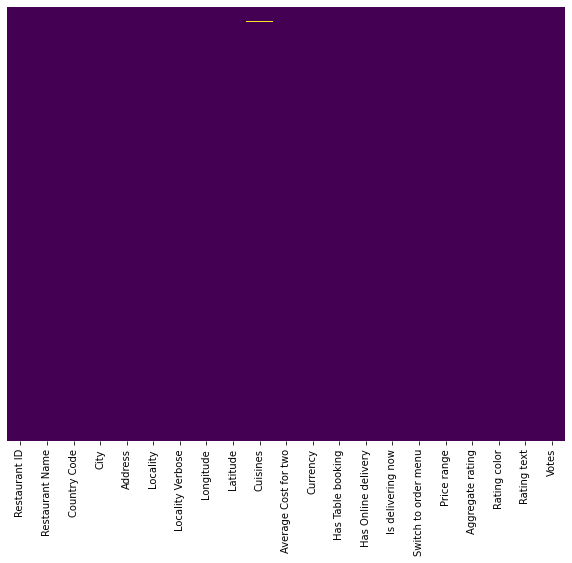

```python
#we are going to check the missing value through the heat map
fig=plt.figure(figsize=(10,8))
sns.heatmap(df.isnull(),yticklabels=False,cbar=False,cmap='viridis')
```

```python
#Now importing the data set of country code
df_country_code=pd.read_excel('D:\data science _2\EDA\Zomatodataset\Country-Code.xlsx')
df_country_code
```

|  | Country Code | Country |
| --- | --- | --- |
| 0 | 1 | India |
| 1 | 14 | Australia |
| 2 | 30 | Brazil |
| 3 | 37 | Canada |
| 4 | 94 | Indonesia |
| 5 | 148 | New Zealand |
| 6 | 162 | Phillipines |
| 7 | 166 | Qatar |
| 8 | 184 | Singapore |
| 9 | 189 | South Africa |
| 10 | 191 | Sri Lanka |
| 11 | 208 | Turkey |
| 12 | 214 | UAE |
| 13 | 215 | United Kingdom |
| 14 | 216 | United States |

```python
df.columns
```

```
Index(['Restaurant ID', 'Restaurant Name', 'Country Code', 'City', 'Address',
       'Locality', 'Locality Verbose', 'Longitude', 'Latitude', 'Cuisines',
       'Average Cost for two', 'Currency', 'Has Table booking',
       'Has Online delivery', 'Is delivering now', 'Switch to order menu',
       'Price range', 'Aggregate rating', 'Rating color', 'Rating text',
       'Votes'],
      dtype='object')
```

Now we are going to merger the country code data frame into the main data frame. We have the name of the country for the each country code and we are adding a column to the data frame that is Country name w.r.t the country code.

We will use (pd.merge) funtion to merger the data frame and (on='County code') here country code is the name of the column of the previous data frame and w.r to it we are adding the respecting name of the country to it.

# basically "on" represents that data match to its element

how="left' we have add the country name into the main data frame that i have passed the argument first, if we put "right' then it will add the to the o=second parameter or might be some error

```python
final_df=pd.merge(df,df_country_code,on='Country Code',how='left')
final_df.head(2)
```

|  | Restaurant ID | Restaurant Name | Country Code | City | Address | Locality | Locality Verbose | Longitude | Latitude | Cuisines | ... | Has Table booking | Has Online delivery | Is delivering now | Switch to order menu | Price range | Aggregate rating | Rating color | Rating text | Votes | Country |
| --- | --- | --- | --- | --- | --- | --- | --- | --- | --- | --- | --- | --- | --- | --- | --- | --- | --- | --- | --- | --- | --- |
| 0 | 6317637 | Le Petit Souffle | 162 | Makati City | Third Floor, Century City Mall, Kalayaan Avenu... | Century City Mall, Poblacion, Makati City | Century City Mall, Poblacion, Makati City, Mak... | 121.027535 | 14.565443 | French, Japanese, Desserts | ... | Yes | No | No | No | 3 | 4.8 | Dark Green | Excellent | 314 | Phillipines |
| 1 | 6304287 | Izakaya Kikufuji | 162 | Makati City | Little Tokyo, 2277 Chino Roces Avenue, Legaspi... | Little Tokyo, Legaspi Village, Makati City | Little Tokyo, Legaspi Village, Makati City, Ma... | 121.014101 | 14.553708 | Japanese | ... | Yes | No | No | No | 3 | 4.5 | Dark Green | Excellent | 591 | Phillipines |

2 rows × 22 columns

```python
##Another option to check the data types is

final_df.dtypes
```

```
Restaurant ID             int64
Restaurant Name          object
Country Code              int64
City                     object
Address                  object
Locality                 object
Locality Verbose         object
Longitude               float64
Latitude                float64
Cuisines                 object
Average Cost for two      int64
Currency                 object
Has Table booking        object
Has Online delivery      object
Is delivering now        object
Switch to order menu     object
Price range               int64
Aggregate rating        float64
Rating color             object
Rating text              object
Votes                     int64
Country                  object
dtype: object
```

```python
#lets the features
final_df.columns
```

```
Index(['Restaurant ID', 'Restaurant Name', 'Country Code', 'City', 'Address',
       'Locality', 'Locality Verbose', 'Longitude', 'Latitude', 'Cuisines',
       'Average Cost for two', 'Currency', 'Has Table booking',
       'Has Online delivery', 'Is delivering now', 'Switch to order menu',
       'Price range', 'Aggregate rating', 'Rating color', 'Rating text',
       'Votes', 'Country'],
      dtype='object')
```

These are the features that is name of the columns

```python
#now checking the smome features
final_df.Country.value_counts()# value_counts() it gives the no of count of each country
```

```
India             8652
United States      434
United Kingdom      80
Brazil              60
UAE                 60
South Africa        60
New Zealand         40
Turkey              34
Australia           24
Phillipines         22
Indonesia           21
Singapore           20
Qatar               20
Sri Lanka           20
Canada               4
Name: Country, dtype: int64
```

```python
country_name=final_df.Country.value_counts().index  #using array storing the name of the country
country_name
```

```
Index(['India', 'United States', 'United Kingdom', 'Brazil', 'UAE',
       'South Africa', 'New Zealand', 'Turkey', 'Australia', 'Phillipines',
       'Indonesia', 'Singapore', 'Qatar', 'Sri Lanka', 'Canada'],
      dtype='object')
```

```python
country_count=final_df.Country.value_counts().values
country_count
```

```
array([8652,  434,   80,   60,   60,   60,   40,   34,   24,   22,   21,
         20,   20,   20,    4], dtype=int64)
```

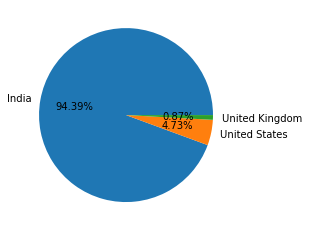

```python
#Drawing pie chart for top three zomato compaany
plt.pie(country_count[:3],labels=country_name[:3],autopct='%1.2f%%')#Here I have used [:3] to know top three country values
plt.show()
```

Observation : Zomato maximum transaction and sale if maximum from India, and then from united states and then u.k

```python
final_df.columns
```

```
Index(['Restaurant ID', 'Restaurant Name', 'Country Code', 'City', 'Address',
       'Locality', 'Locality Verbose', 'Longitude', 'Latitude', 'Cuisines',
       'Average Cost for two', 'Currency', 'Has Table booking',
       'Has Online delivery', 'Is delivering now', 'Switch to order menu',
       'Price range', 'Aggregate rating', 'Rating color', 'Rating text',
       'Votes', 'Country'],
      dtype='object')
```

we are going to check data rating wise

```python
rating=final_df.groupby(['Aggregate rating','Rating color', 'Rating text']).size().reset_index().rename(columns={0:"Rating Count"})
rating
```

|  | Aggregate rating | Rating color | Rating text | Rating Count |
| --- | --- | --- | --- | --- |
| 0 | 0.0 | White | Not rated | 2148 |
| 1 | 1.8 | Red | Poor | 1 |
| 2 | 1.9 | Red | Poor | 2 |
| 3 | 2.0 | Red | Poor | 7 |
| 4 | 2.1 | Red | Poor | 15 |
| 5 | 2.2 | Red | Poor | 27 |
| 6 | 2.3 | Red | Poor | 47 |
| 7 | 2.4 | Red | Poor | 87 |
| 8 | 2.5 | Orange | Average | 110 |
| 9 | 2.6 | Orange | Average | 191 |
| 10 | 2.7 | Orange | Average | 250 |
| 11 | 2.8 | Orange | Average | 315 |
| 12 | 2.9 | Orange | Average | 381 |
| 13 | 3.0 | Orange | Average | 468 |
| 14 | 3.1 | Orange | Average | 519 |
| 15 | 3.2 | Orange | Average | 522 |
| 16 | 3.3 | Orange | Average | 483 |
| 17 | 3.4 | Orange | Average | 498 |
| 18 | 3.5 | Yellow | Good | 480 |
| 19 | 3.6 | Yellow | Good | 458 |
| 20 | 3.7 | Yellow | Good | 427 |
| 21 | 3.8 | Yellow | Good | 400 |
| 22 | 3.9 | Yellow | Good | 335 |
| 23 | 4.0 | Green | Very Good | 266 |
| 24 | 4.1 | Green | Very Good | 274 |
| 25 | 4.2 | Green | Very Good | 221 |
| 26 | 4.3 | Green | Very Good | 174 |
| 27 | 4.4 | Green | Very Good | 144 |
| 28 | 4.5 | Dark Green | Excellent | 95 |
| 29 | 4.6 | Dark Green | Excellent | 78 |
| 30 | 4.7 | Dark Green | Excellent | 42 |
| 31 | 4.8 | Dark Green | Excellent | 25 |
| 32 | 4.9 | Dark Green | Excellent | 61 |

# conslusion

1.Whenever the rating is between 4.5 to 4.9 is excellent, when ratings are between 4.0 to 4.4 the rating are very good, when the rating is 3.5 to 3.9 then rating is good, when rating is between 2.5 to 3.4 the rating is average ,

2.Many people did n't rated yet

```python
rating.head()
```

|  | Aggregate rating | Rating color | Rating text | Rating Count |
| --- | --- | --- | --- | --- |
| 0 | 0.0 | White | Not rated | 2148 |
| 1 | 1.8 | Red | Poor | 1 |
| 2 | 1.9 | Red | Poor | 2 |
| 3 | 2.0 | Red | Poor | 7 |
| 4 | 2.1 | Red | Poor | 15 |

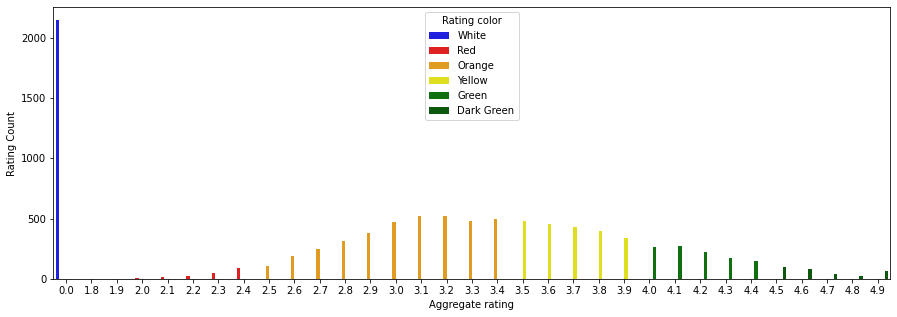

```python
fig=plt.figure(figsize=(15,5))
sns.barplot(x="Aggregate rating",y="Rating Count",hue='Rating color',data=rating,palette=["Blue","Red","Orange","Yellow","Green","DarkGreen"])
```

Observatio:

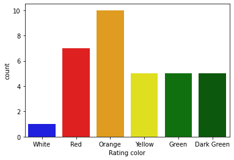

```python
##count plot w.r.t color

sns.countplot(x="Rating color",data=rating,palette=["Blue","Red","Orange","Yellow","Green","DarkGreen"])
```

```python
rating
```

|  | Aggregate rating | Rating color | Rating text | Rating Count |
| --- | --- | --- | --- | --- |
| 0 | 0.0 | White | Not rated | 2148 |
| 1 | 1.8 | Red | Poor | 1 |
| 2 | 1.9 | Red | Poor | 2 |
| 3 | 2.0 | Red | Poor | 7 |
| 4 | 2.1 | Red | Poor | 15 |
| 5 | 2.2 | Red | Poor | 27 |
| 6 | 2.3 | Red | Poor | 47 |
| 7 | 2.4 | Red | Poor | 87 |
| 8 | 2.5 | Orange | Average | 110 |
| 9 | 2.6 | Orange | Average | 191 |
| 10 | 2.7 | Orange | Average | 250 |
| 11 | 2.8 | Orange | Average | 315 |
| 12 | 2.9 | Orange | Average | 381 |
| 13 | 3.0 | Orange | Average | 468 |
| 14 | 3.1 | Orange | Average | 519 |
| 15 | 3.2 | Orange | Average | 522 |
| 16 | 3.3 | Orange | Average | 483 |
| 17 | 3.4 | Orange | Average | 498 |
| 18 | 3.5 | Yellow | Good | 480 |
| 19 | 3.6 | Yellow | Good | 458 |
| 20 | 3.7 | Yellow | Good | 427 |
| 21 | 3.8 | Yellow | Good | 400 |
| 22 | 3.9 | Yellow | Good | 335 |
| 23 | 4.0 | Green | Very Good | 266 |
| 24 | 4.1 | Green | Very Good | 274 |
| 25 | 4.2 | Green | Very Good | 221 |
| 26 | 4.3 | Green | Very Good | 174 |
| 27 | 4.4 | Green | Very Good | 144 |
| 28 | 4.5 | Dark Green | Excellent | 95 |
| 29 | 4.6 | Dark Green | Excellent | 78 |
| 30 | 4.7 | Dark Green | Excellent | 42 |
| 31 | 4.8 | Dark Green | Excellent | 25 |
| 32 | 4.9 | Dark Green | Excellent | 61 |

```python
##finding the name of the countries who has given zero rating

Countrie_name_rating=final_df[final_df["Aggregate rating"]==0.0].groupby(["Country"]).size().reset_index().rename(columns={0:"Count"})
Countrie_name_rating
```

|  | Country | Count |
| --- | --- | --- |
| 0 | Brazil | 5 |
| 1 | India | 2139 |
| 2 | United Kingdom | 1 |
| 3 | United States | 3 |

```python
another_way=final_df.groupby(['Aggregate rating','Country']).size().reset_index().head(4)
another_way
```

|  | Aggregate rating | Country | 0 |
| --- | --- | --- | --- |
| 0 | 0.0 | Brazil | 5 |
| 1 | 0.0 | India | 2139 |
| 2 | 0.0 | United Kingdom | 1 |
| 3 | 0.0 | United States | 3 |

Obseravatio:

1. Maximum people are fromn india who has not rated

# find out which courrency is used by each ountry

```python
final_df.columns
```

```
Index(['Restaurant ID', 'Restaurant Name', 'Country Code', 'City', 'Address',
       'Locality', 'Locality Verbose', 'Longitude', 'Latitude', 'Cuisines',
       'Average Cost for two', 'Currency', 'Has Table booking',
       'Has Online delivery', 'Is delivering now', 'Switch to order menu',
       'Price range', 'Aggregate rating', 'Rating color', 'Rating text',
       'Votes', 'Country'],
      dtype='object')
```

We are going to check which country using which currency

```python
currency_by_country_name=final_df.groupby(['Country','Currency']).size().reset_index().rename(columns={0:'Count of Country'})
currency_by_country_name
```

[output not shown]

# NOW are going to check which country has online delivery and whcih has not

```python
final_df.columns
```

```
Index(['Restaurant ID', 'Restaurant Name', 'Country Code', 'City', 'Address',
       'Locality', 'Locality Verbose', 'Longitude', 'Latitude', 'Cuisines',
       'Average Cost for two', 'Currency', 'Has Table booking',
       'Has Online delivery', 'Is delivering now', 'Switch to order menu',
       'Price range', 'Aggregate rating', 'Rating color', 'Rating text',
       'Votes', 'Country'],
      dtype='object')
```

```python
final_df.groupby(['Country','Has Online delivery']).size().reset_index()
```

|  | Country | Has Online delivery | 0 |
| --- | --- | --- | --- |
| 0 | Australia | No | 24 |
| 1 | Brazil | No | 60 |
| 2 | Canada | No | 4 |
| 3 | India | No | 6229 |
| 4 | India | Yes | 2423 |
| 5 | Indonesia | No | 21 |
| 6 | New Zealand | No | 40 |
| 7 | Phillipines | No | 22 |
| 8 | Qatar | No | 20 |
| 9 | Singapore | No | 20 |
| 10 | South Africa | No | 60 |
| 11 | Sri Lanka | No | 20 |
| 12 | Turkey | No | 34 |
| 13 | UAE | No | 32 |
| 14 | UAE | Yes | 28 |
| 15 | United Kingdom | No | 80 |
| 16 | United States | No | 434 |

```python
final_df[final_df['Has Online delivery']=='Yes'].groupby(final_df["Country"]).size().reset_index()
```

|  | Country | 0 |
| --- | --- | --- |
| 0 | India | 2423 |
| 1 | UAE | 28 |

```python
final_df[final_df['Has Online delivery']=='Yes'].Country.value_counts()
```

```
India    2423
UAE        28
Name: Country, dtype: int64
```

## Observation :

1. India and UAE has online delivery available

## ONLINE AVAILABLE CITY WISE

```python
final_df[final_df['Has Online delivery']=='Yes'].City.value_counts()
```

```
New Delhi       1489
Gurgaon          425
Noida            364
Faridabad         35
Chennai           13
Abu Dhabi         11
Sharjah           11
Ahmedabad         11
Ghaziabad         10
Nagpur            10
Jaipur            10
Kolkata            8
Pune               7
Mumbai             7
Hyderabad          7
Coimbatore         7
Bangalore          7
Dubai              6
Chandigarh         6
Kochi              5
Mohali             1
Secunderabad       1
Name: City, dtype: int64
```

```python
final_df[final_df['Has Online delivery']=='Yes'].groupby('City').size().reset_index()
```

|  | City | 0 |
| --- | --- | --- |
| 0 | Abu Dhabi | 11 |
| 1 | Ahmedabad | 11 |
| 2 | Bangalore | 7 |
| 3 | Chandigarh | 6 |
| 4 | Chennai | 13 |
| 5 | Coimbatore | 7 |
| 6 | Dubai | 6 |
| 7 | Faridabad | 35 |
| 8 | Ghaziabad | 10 |
| 9 | Gurgaon | 425 |
| 10 | Hyderabad | 7 |
| 11 | Jaipur | 10 |
| 12 | Kochi | 5 |
| 13 | Kolkata | 8 |
| 14 | Mohali | 1 |
| 15 | Mumbai | 7 |
| 16 | Nagpur | 10 |
| 17 | New Delhi | 1489 |
| 18 | Noida | 364 |
| 19 | Pune | 7 |
| 20 | Secunderabad | 1 |
| 21 | Sharjah | 11 |

## Now I am going to check which city has maximum no of transactions

```python
final_df.columns
```

```
Index(['Restaurant ID', 'Restaurant Name', 'Country Code', 'City', 'Address',
       'Locality', 'Locality Verbose', 'Longitude', 'Latitude', 'Cuisines',
       'Average Cost for two', 'Currency', 'Has Table booking',
       'Has Online delivery', 'Is delivering now', 'Switch to order menu',
       'Price range', 'Aggregate rating', 'Rating color', 'Rating text',
       'Votes', 'Country'],
      dtype='object')
```

```python
city_name=final_df.City.value_counts().index
city_tran=final_df.City.value_counts().values
```

[output not shown]

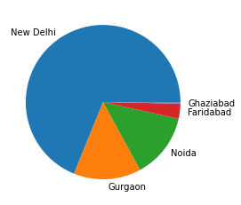

```python
plt.pie(city_tran[:5],labels=city_name[:5])
```

## Observatio:

1. Delhi is top 1 city here the more tansaction is happening

```python
final_df.columns
```

```
Index(['Restaurant ID', 'Restaurant Name', 'Country Code', 'City', 'Address',
       'Locality', 'Locality Verbose', 'Longitude', 'Latitude', 'Cuisines',
       'Average Cost for two', 'Currency', 'Has Table booking',
       'Has Online delivery', 'Is delivering now', 'Switch to order menu',
       'Price range', 'Aggregate rating', 'Rating color', 'Rating text',
       'Votes', 'Country'],
      dtype='object')
```